# Simulate data

# Simulation data 1: Sharp RDD

Here we will simulate the setting in which there is a simple causal effect of tPA administration on clinical outcome. In this dataset, we will assume that the threshold for tPA administration (3 hours) is always followed, meaning that there should be a sharp discontinuity between outcomes on the left side of the threshold and on the right.

We will simulate the sorting variable, $x$ (time until hospital presentation), and the outcome (1=good,0=bad). We will model the probability of a good outcome as depending linearly on $x$, with a discontuinty at the threshold for tPA administration (3 hours).

First, we will simulate the sorting variable, $x$, the time until presentation at the hospital. For the sake of simplicity, these values will be sampled uniformly between the two desired endpoints ($x_{min}$ and $x_{max}$).

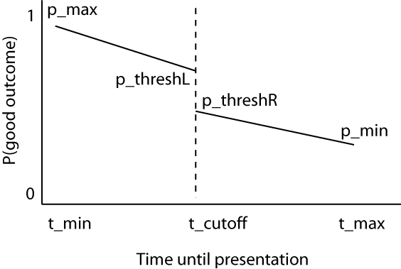

Data simulation schematic: Sharp RDD

```r
n <- 10000 # Number of samples desired
x_min <- 160 # In minutes
x_max <- 200
x <- runif(n = n ,min = x_min, max = x_max)
```

Define desired values

```r
c <- 180
p_max <- .8
p_thresh_left <- .7
p_thresh_right <- .3
p_min <- .2
```

Build linear functions for simulation on the left side of threshold:
$$p_{threshL} - p_{max} = m (c - x_{min})$$
$$p_{max} = mx + b$$

```r
# Slope
m_left <- (p_thresh_left - p_max)/(c - x_min)
# Intercept
b_left <- p_max - m_left*x_min
```

Build linear functions on the right side of the threshold
$$p_{min} - p_{threshR} = m(x_{max} - c)$$
$$p_{min} = mx + b$$

```r
# Slope
m_right <- (p_min - p_thresh_right)/(x_max - c)
# Intercept
b_right <- p_min - m_right*x_max
```

Simulate the data

```r
y <- rep(0,n)
p_temp <- rep(0,n)

for(i in 1:n){
    if (x[i] < c){
        p_temp[i] <- m_left*x[i] + b_left
        y[i] <- rbinom(1,1,p_temp[i])
    } else {
        p_temp[i] <- m_right*x[i] + b_right
        y[i] <- rbinom(1,1,p_temp[i])
    }
}
```

### Plot data and functions that generated them

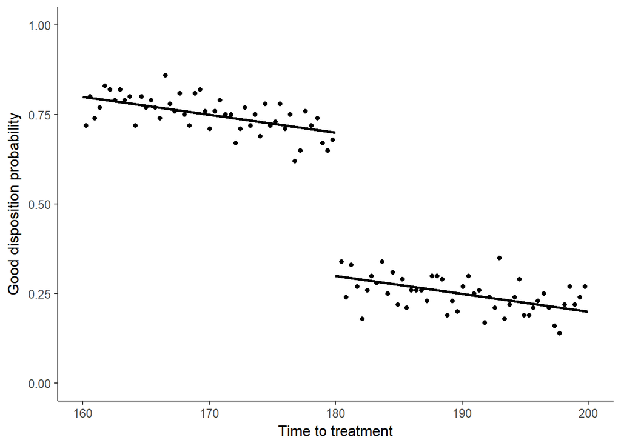

```r
library(ggplot2)
# Generate data for lines
x1 <- seq(from=160,to=180,by=.01)
x2 <- seq(from=180,to=200,by=.01)
y1 <- m_left*x1 + b_left
y2 <- m_right*x2 + b_right

# Generate bin means
bin_size <- 100
xbin1 <- x[x<180]
ybin1 <- y[x<180]
ptemp1 <- p_temp[x<180]
ptemp1 <- p_temp[order(xbin1)]
ybin1 <- ybin1[order(xbin1)]
xbin1 <- xbin1[order(xbin1)]
num_remove1 <- length(ybin1) %% bin_size
elements_remove1 <- seq(from=1,to=num_remove1)
xbin1 <- xbin1[-elements_remove1]
ybin1 <- ybin1[-elements_remove1]

xbin2 <- x[x>180]
ybin2 <- y[x>180]
ptemp2 <- p_temp[x>180]
ybin2 <- ybin2[order(xbin2)]
ptemp2 <- ptemp2[order(xbin2)]
xbin2 <- xbin2[order(xbin2)]
num_remove2 <- length(ybin2) %% bin_size
elements_remove2 <- seq(from=1,to=num_remove2)
xbin2 <- xbin2[-elements_remove2]
ybin2 <- ybin2[-elements_remove2]

ybin1 <- matrix(ybin1,ncol=bin_size,byrow=TRUE)
xbin1 <- matrix(xbin1,ncol=bin_size,byrow=TRUE)
ybin2 <- matrix(ybin2,ncol=bin_size,byrow=TRUE)
xbin2 <- matrix(xbin2,ncol=bin_size,byrow=TRUE)
ymeans1 <- rowMeans(ybin1)
xmeans1 <- rowMeans(xbin1)
ymeans2 <- rowMeans(ybin2)
xmeans2 <- rowMeans(xbin2)


df1 <- data.frame(xx=x1,yy=y1) # left line
df2 <- data.frame(xx=x2,yy=y2) # right line
df3 <- data.frame(xx=xmeans1,yy=ymeans1)
df4 <- data.frame(xx=xmeans2,yy=ymeans2)

# Plot
(plot1 <- ggplot(df1, aes(xx,yy)) +
    geom_line(size=1) +
    geom_line(data = df2,size=1) +
    geom_point(data=df3) +
    geom_point(data=df4) +
    xlab("Time to treatment") +
    ylab("Good disposition probability") +
    theme_classic(base_size = 12) +
    ylim(0,1) +
    xlim(160,200)
)
```

### Package `rdd`

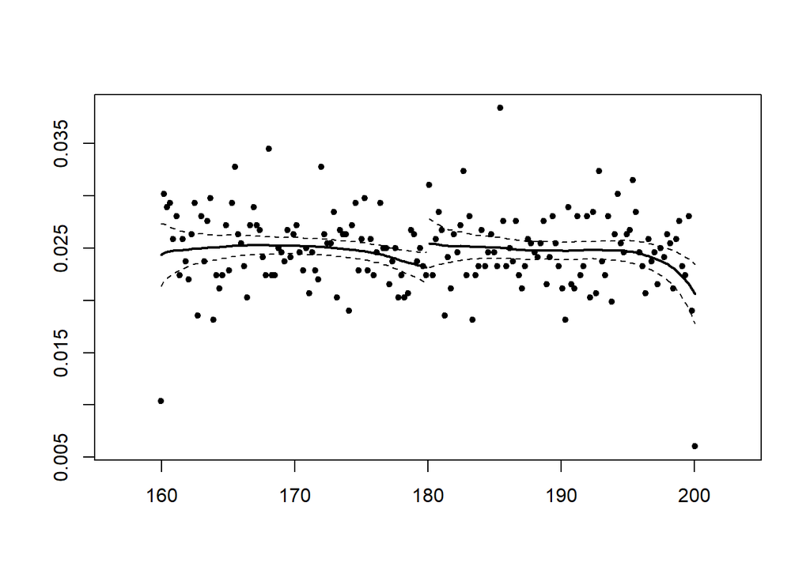

```
## [1] 0.1636577
```

```r
bw_desired = 20 #in minutes
library(rdd)
bw <- IKbandwidth(X=x,Y=y,cutpoint=c)
DCdensity(runvar = x,cutpoint = c)
```

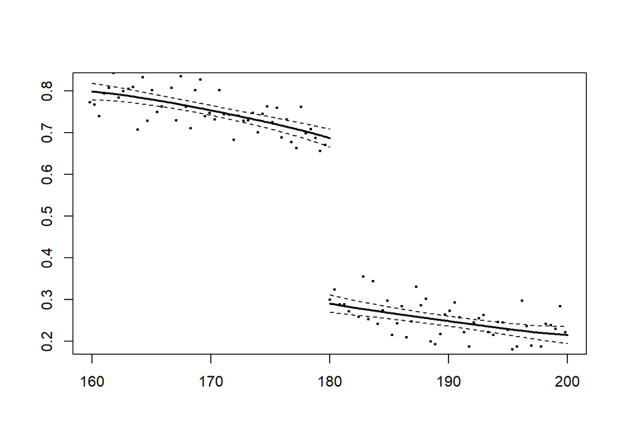

```r
rd <- RDestimate(y~x,cutpoint=c,bw = bw_desired)
plot(rd)
```

```r
summary(rd)
```

```
##
## Call:
## RDestimate(formula = y ~ x, cutpoint = c, bw = bw_desired)
##
## Type:
## sharp
##
## Estimates:
##            Bandwidth  Observations  Estimate  Std. Error  z value
## LATE       20         10000         -0.3968   0.01998     -19.86
## Half-BW    10          4975         -0.3868   0.02876     -13.45
## Double-BW  40         10000         -0.4058   0.01823     -22.27
##            Pr(>|z|)
## LATE        8.652e-88  ***
## Half-BW     3.014e-41  ***
## Double-BW  7.614e-110  ***
## ---
## Signif. codes:  0 '***' 0.001 '**' 0.01 '*' 0.05 '.' 0.1 ' ' 1
##
## F-statistics:
##            F       Num. DoF  Denom. DoF  p
## LATE        974.2  3         9996        0
## Half-BW     388.5  3         4971        0
## Double-BW  1090.9  3         9996        0
```

### Package `rdrobust`

```r
bw_desired = 20 #in minutes
library(rdrobust)
rdbwselect(y=y,x=x,c = c,all=TRUE)
```

```
## Call: rdbwselect
##
## Number of Obs.                10000
## BW type                         All
## Kernel                   Triangular
## VCE method                       NN
##
## Number of Obs.                5023        4977
## Order est. (p)                   1           1
## Order bias  (p)                  2           2
```

```r
rdrobust(y = y,x = x,c = c, h = bw_desired)
```

```
## Call: rdrobust
##
## Number of Obs.                10000
## BW type                      Manual
## Kernel                   Triangular
## VCE method                       NN
##
## Number of Obs.                5023        4977
## Eff. Number of Obs.           5023        4977
## Order est. (p)                   1           1
## Order bias  (p)                  2           2
## BW est. (h)                 20.000      20.000
## BW bias (b)                 20.000      20.000
## rho (h/b)                    1.000       1.000
```

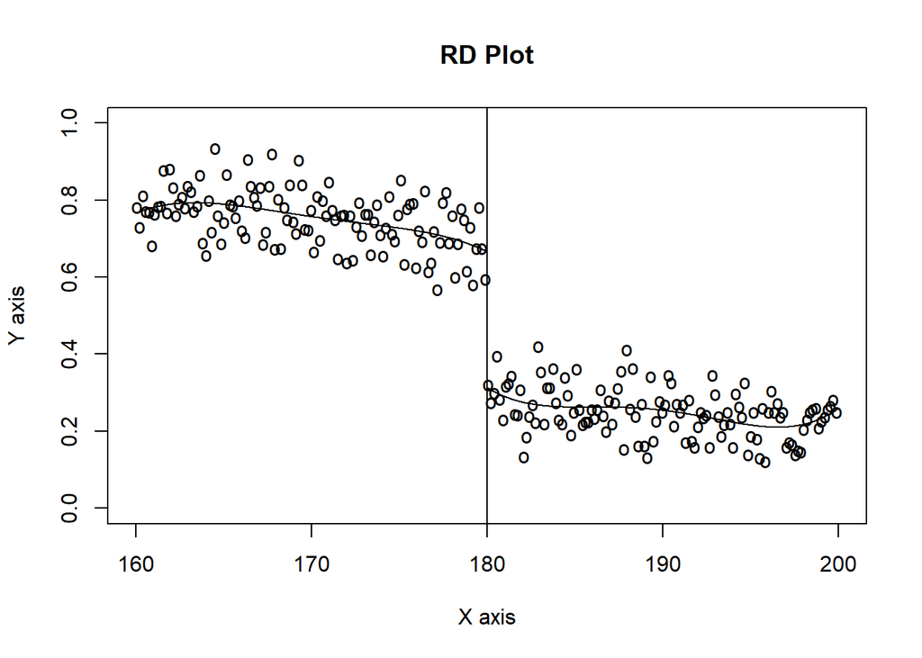

```r
rdplot(y = y,x = x,c = c,col.lines = "black",type.dots = "open")
```